# Weighted Gene Coexpression Analysis

MOLab

2024-11-14

# Overview

Co-expression analysis is a powerful approach in systems biology for identifying genes with similar expression patterns across multiple conditions or samples, revealing potential functional relationships or shared regulatory mechanisms. By grouping genes into modules based on their expression similarity, co-expression analysis helps uncover biologically meaningful clusters associated with specific phenotypes or environmental factors. Weighted Gene Co-expression Network Analysis (WGCNA) is a widely used tool for this purpose, providing a robust framework to construct co-expression networks and identify modules of highly correlated genes. WGCNA also facilitates downstream analyses, such as linking gene modules to external traits or identifying hub genes, which can serve as potential biomarkers or targets for further investigation.

# Referencess

[WGCNA Tutorial Documentations and FAQs](https://www.dropbox.com/scl/fo/4vqfiysan6rlurfo2pbnk/h?rlkey=thqg8wlpdn4spu3ihjuc1kmlu&dl=0)

# Load Libraries

```r
library(WGCNA)
library(airway)
library(DT)
library(ggplot2)
```

# Data Preparation

## `airway` Demo Data

### Feature Table

For demonstration purposes, we will be using a dataset available in the `airway` package. The RNA-seq experiment consists four samples of each treatment group (dexamethasone versus placebo). We can see more information about the data in the following commands.

**Warning:** The WGCNA authors recommend a minimum of 15 samples when working with WGCNA. The demo data used in this module contains only 8 samples. Nonetheless, we will proceed for the sake of showing the workflow.

```r
data('airway')
counts_matrix <- as.data.frame(assay(airway, "counts"))
```

The first 50 rows of the counts matrix is shown below.

|  | SRR1039508 | SRR1039509 | SRR1039512 | SRR1039513 | SRR1039516 | SRR1039517 | SRR1039520 | SRR1039521 |
| --- | --- | --- | --- | --- | --- | --- | --- | --- |
| ENSG00000000003 | 679 | 448 | 873 | 408 | 1138 | 1047 | 770 | 572 |
| ENSG00000000005 | 0 | 0 | 0 | 0 | 0 | 0 | 0 | 0 |
| ENSG00000000419 | 467 | 515 | 621 | 365 | 587 | 799 | 417 | 508 |
| ENSG00000000457 | 260 | 211 | 263 | 164 | 245 | 331 | 233 | 229 |
| ENSG00000000460 | 60 | 55 | 40 | 35 | 78 | 63 | 76 | 60 |
| ENSG00000000938 | 0 | 0 | 2 | 0 | 1 | 0 | 0 | 0 |
| ENSG00000000971 | 3251 | 3679 | 6177 | 4252 | 6721 | 11027 | 5176 | 7995 |
| ENSG00000001036 | 1433 | 1062 | 1733 | 881 | 1424 | 1439 | 1359 | 1109 |
| ENSG00000001084 | 519 | 380 | 595 | 493 | 820 | 714 | 696 | 704 |
| ENSG00000001167 | 394 | 236 | 464 | 175 | 658 | 584 | 360 | 269 |

[output cut: 40 more lines]

### Metadata

Additionally, we will also make use of the metadata file associated with the samples.

```r
sample_metadata <- as.data.frame(colData(airway))
```

```r
str(sample_metadata)
```

```
## 'data.frame':    8 obs. of  9 variables:
##  $ SampleName: Factor w/ 8 levels "GSM1275862","GSM1275863",..: 1 2 3 4 5 6 7 8
##  $ cell      : Factor w/ 4 levels "N052611","N061011",..: 4 4 1 1 3 3 2 2
##  $ dex       : Factor w/ 2 levels "trt","untrt": 2 1 2 1 2 1 2 1
##  $ albut     : Factor w/ 1 level "untrt": 1 1 1 1 1 1 1 1
##  $ Run       : Factor w/ 8 levels "SRR1039508","SRR1039509",..: 1 2 3 4 5 6 7 8
##  $ avgLength : int  126 126 126 87 120 126 101 98
##  $ Experiment: Factor w/ 8 levels "SRX384345","SRX384346",..: 1 2 3 4 5 6 7 8
##  $ Sample    : Factor w/ 8 levels "SRS508567","SRS508568",..: 2 1 3 4 5 6 7 8
##  $ BioSample : Factor w/ 8 levels "SAMN02422669",..: 1 4 6 2 7 3 8 5
```

## Loading Your Own Data

**Click to expand**

### TSV

If you want to use your own data, you can generate a count matrix using the `varianceStabilizingTransformation()` function available in `DESeq2` package (see **Differential Expression Analysis Module**). If you have exported the transformed count table (as TSV), you can then import it back using the `read.table()` function. The table should contain the samples in the columns and the features/transcripts in the rows.

```r
counts_matrix <- read.table(
  'vst_counts.tsv',
  sep='\t',
  row.names=1
)
```

### Metadata

Similarly, we import the metadata file. The samples should be indicated in the rows, and the variables in the columns.

```r
sample_metadata <- read.table(
  'metadata.tsv',
  sep='\t',
  row.names=1
)
```

## Check Samples and Features

Below, we explore samples and features that are “bad” (i.e. zero variance, missing entries, etc.)

```r
gsg <- goodSamplesGenes(t(counts_matrix), verbose=3)
```

```
##  Flagging genes and samples with too many missing values...
##   ..step 1
##   ..Excluding 30633 genes from the calculation due to too many missing samples or zero variance.
##   ..step 2
```

Check if all samples are good.

```r
gsg$goodSamples
```

```
## [1] TRUE TRUE TRUE TRUE TRUE TRUE TRUE TRUE
```

We see that there are genes that were flagged as “bad” in the standard output of `goodSamplesGenes()`. Before we proceed, we remove those “bad” features.

```r
filt_counts_matr <- as.data.frame(t(t(counts_matrix)[, gsg$goodGenes]))
dim(filt_counts_matr)
```

```
## [1] 33469     8
```

# Filter Expression Matrix

Filtering the expression matrix serves two primary purposes:

1. Reducing dataset dimensionality: This lowers memory requirements and enhances computational efficiency.
2. Minimizing noise: By removing transcripts with low information value, we can improve the reliability of downstream analyses.

Several filtering criteria can be applied, but here we focus on filtering transcripts based on their variance. The rationale is that transcripts with low variance are less likely to correlate meaningfully with other transcripts and, therefore, contribute little to the construction of co-expression networks in WGCNA.

## Per-feature Variance

Calculate the row-wise variance of the filtered counts matrix, then sort the features from highest to lowest variance.

```r
rv <- rowVars(as.matrix(filt_counts_matr), useNames=T)
rv2 <- data.frame(
  Seq=seq(1:nrow(filt_counts_matr)),
  rowVars=rv[order(rv, decreasing=TRUE)]
)
```

The first few lines of the resulting dataframe is shown below.

|  | Seq | rowVars |
| --- | --- | --- |
| ENSG00000166923 | 1 | 10214468569.125 |
| ENSG00000115414 | 2 | 9710042010.839285 |
| ENSG00000011465 | 3 | 7473690654 |
| ENSG00000198804 | 4 | 7466323045.553572 |
| ENSG00000115461 | 5 | 7426014885.267858 |
| ENSG00000087086 | 6 | 6748078255.071428 |
| ENSG00000103888 | 7 | 6472195779.410714 |
| ENSG00000137801 | 8 | 4967759027.142858 |
| ENSG00000210082 | 9 | 4099702303.125 |
| ENSG00000141753 | 10 | 3339521387.428571 |

[output cut: 10 more lines]

## Visualize Variance Distribution

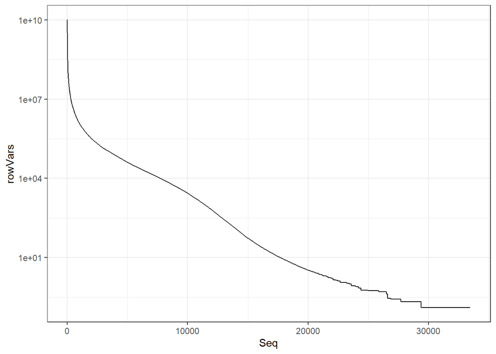

```r
rv2 %>%
  ggplot(aes(x=Seq, y=rowVars)) +
  geom_line() +
  theme_bw() +
  scale_y_log10()
```

## Filter

Now we filter the expression matrix based on a pre-defined criterion. First we select the transcripts that pass the threshold.

```r
pct_thresh <- 0.5
filt_transcripts <- row.names(rv2)[1:round(dim(rv2)[1]*pct_thresh)]
```

Finally, filter the table based on the selected transcripts (`filt_transcripts`).

```r
varfilt_counts_matr <- filt_counts_matr[filt_transcripts, ]
```

# Soft-Thresholding ($\beta$) Parameter

In WGCNA, the $\beta$ parameter (where $\beta\geq1$) places weights on the correlation between two nodes (features). The equation below shows the weighted adjacency measure ($a_{ij}$) between nodes $i$ and $j$, where $s_{ij}$ is the correlation coefficient between the said nodes.

$$a_{ij}=s_{ij}^{\beta}$$

This power transformation penalizes weak correlations more heavily, effectively reducing noise in the network. Additionally, it facilitates the construction of networks that approximate a scale-free topology (SFT; i.e. only a few hub genes), a key assumption in WGCNA.

You can see more discussion about these topics in WGCNA’s [manual](https://www.dropbox.com/scl/fo/4vqfiysan6rlurfo2pbnk/h?rlkey=thqg8wlpdn4spu3ihjuc1kmlu&e=1&dl=0) and in their [publication](https://bmcbioinformatics.biomedcentral.com/articles/10.1186/1471-2105-9-559).

In the following sections, we will identify what $\beta$ parameter to use for network construction

## Selection of $\beta$

First, we define the range of $\beta$ parameters to test for.

```r
powers <- c(c(4:10), seq(from=12, to=40, by=2))
```

Then use the `pickSoftThreshold()` function to calculate metrics that will aid in the selection of $\beta$ that yields a network with a scale-free topology. We also note that we are calculating for a signed network.

```r
sft <- pickSoftThreshold(
  t(varfilt_counts_matr),
  powerVector=powers,
  verbose=5,
  networkType="signed"
)
```

```
## pickSoftThreshold: will use block size 2673.
##  pickSoftThreshold: calculating connectivity for given powers...
##    ..working on genes 1 through 2673 of 16734
##    ..working on genes 2674 through 5346 of 16734
##    ..working on genes 5347 through 8019 of 16734
##    ..working on genes 8020 through 10692 of 16734
##    ..working on genes 10693 through 13365 of 16734
##    ..working on genes 13366 through 16038 of 16734
##    ..working on genes 16039 through 16734 of 16734
##    Power SFT.R.sq   slope truncated.R.sq mean.k. median.k. max.k.
## 1      4   0.9240  0.8040         0.9370    6230      6850   9470
## 2      5   0.8590  0.5090         0.8990    5300      5820   8610
## 3      6   0.7240  0.3160         0.7760    4580      4990   7900
## 4      7   0.4270  0.1730         0.4430    4020      4320   7300
## 5      8   0.0858  0.0614        -0.0297    3560      3780   6790
## 6      9   0.0177 -0.0291        -0.2200    3180      3320   6340
## 7     10   0.1820 -0.1070        -0.0462    2860      2940   5940
## 8     12   0.4820 -0.2320         0.3430    2360      2340   5270
## 9     14   0.6190 -0.3320         0.5360    1980      1900   4730
## 10    16   0.6820 -0.4160         0.6340    1690      1560   4280
## 11    18   0.7030 -0.4870         0.6800    1460      1300   3910
## 12    20   0.7270 -0.5490         0.7260    1270      1100   3580
## 13    22   0.7420 -0.6080         0.7560    1120       930   3310
## 14    24   0.7550 -0.6550         0.7810     992       797   3060
## 15    26   0.7610 -0.6970         0.7960     886       690   2850
## 16    28   0.7650 -0.7370         0.8090     795       600   2660
## 17    30   0.7620 -0.7760         0.8120     718       523   2490
## 18    32   0.7660 -0.8100         0.8240     651       460   2330
## 19    34   0.7650 -0.8470         0.8270     593       407   2190
## 20    36   0.7570 -0.8800         0.8240     542       361   2070
## 21    38   0.7560 -0.9080         0.8290     497       322   1950
## 22    40   0.7580 -0.9350         0.8360     457       289   1850
```

Below, we can see different metrics describing the network using different $\beta$ parameters.

```r
datatable(sft$fitIndices, options=list(scrollX=T))
```

|  | Power | SFT.R.sq | slope | truncated.R.sq | mean.k. | median.k. | max.k. |
| --- | --- | --- | --- | --- | --- | --- | --- |
| 1 | 4 | 0.9235181271931275 | 0.8037361236788785 | 0.9369300023639011 | 6230.039423496672 | 6851.472858699939 | 9473.383015899552 |
| 2 | 5 | 0.8585926112300575 | 0.5093382681176108 | 0.8990641954852383 | 5300.61644165356 | 5817.160610827532 | 8613.411746495492 |
| 3 | 6 | 0.7237261567151838 | 0.3164143454782615 | 0.7756305119440342 | 4584.985639739493 | 4987.884581644807 | 7902.4580115842 |
| 4 | 7 | 0.4274859601685386 | 0.1733088890783064 | 0.4430244742576602 | 4017.636594146902 | 4320.870956272147 | 7301.638034901047 |
| 5 | 8 | 0.08582734999811972 | 0.0614326394833118 | -0.02969997094982357 | 3557.470178227989 | 3779.145130544182 | 6785.20408783825 |
| 6 | 9 | 0.0177304188804666 | -0.02909068094511174 | -0.2197191185283907 | 3177.348621983481 | 3324.913812162216 | 6335.280998128696 |
| 7 | 10 | 0.181777379768979 | -0.1071611345462736 | -0.04618168315294269 | 2858.60078527311 | 2942.272957100386 | 5938.978713556715 |
| 8 | 12 | 0.4821193026999964 | -0.2316449728312109 | 0.3427402201827273 | 2355.652371094944 | 2343.456680150612 | 5271.161051852887 |
| 9 | 14 | 0.6187212376761936 | -0.3315282094143827 | 0.5364754714823983 | 1978.779905455289 | 1899.224182004405 | 4728.591914331902 |
| 10 | 16 | 0.6816790768446992 | -0.4164818198553509 | 0.6340111244088061 | 1687.630796962747 | 1562.704084934117 | 4281.830156012607 |

[output cut: 12 more lines]

## Visualize `pickSoftThreshold()` Results

According to the WGCNA [FAQ](https://www.dropbox.com/scl/fo/4vqfiysan6rlurfo2pbnk/h/faq.html?rlkey=thqg8wlpdn4spu3ihjuc1kmlu&dl=0), the scale-free topology (SFT) fit index (first graph below) should be at least 0.8, and the mean connectivity (second graph below) should be below the hundreds. These criteria are designed to ensure that the network adheres to a scale-free topology.

However, as shown below, none of the tested $\beta$ values satisfy both criteria. This outcome may be due to strong drivers in the experiment (e.g. batch effects, treatments, etc.), resulting in a large group of genes with strong correlations.

In cases where SFT criteria are not met, the WGCNA authors recommend alternative approaches. A snippet of their recommendation is provided in the table below.

| Number of Sample | Unsigned and Hybrid Networks | Signed Networks |
| --- | --- | --- |
| $<20$ | 9 | 18 |
| $20-30$ | 8 | 16 |
| $30-40$ | 7 | 14 |
| $>40$ | 6 | 12 |

Based on the table above, we select $\beta=18$ as the soft-thresholding parameter.

### Scale independence versus $\beta$

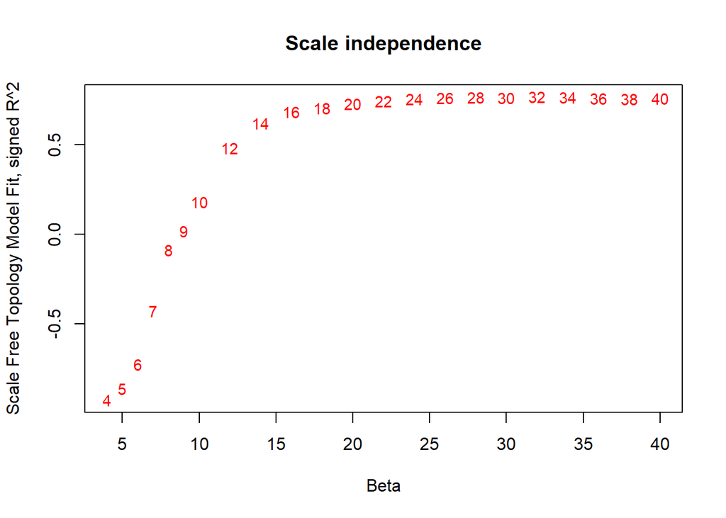

```r
cex1 = 0.9

plot(
  sft$fitIndices[, 1],
  -sign(sft$fitIndices[, 3])*sft$fitIndices[, 2],
  xlab="Beta", ylab="Scale Free Topology Model Fit, signed R^2",
  type="n",
  main=paste("Scale independence"))
text(
  sft$fitIndices[,1],
  -sign(sft$fitIndices[,3])*sft$fitIndices[,2],
  labels=powers,
  cex=cex1,
  col="red")
```

### Mean connectivity versus $\beta$

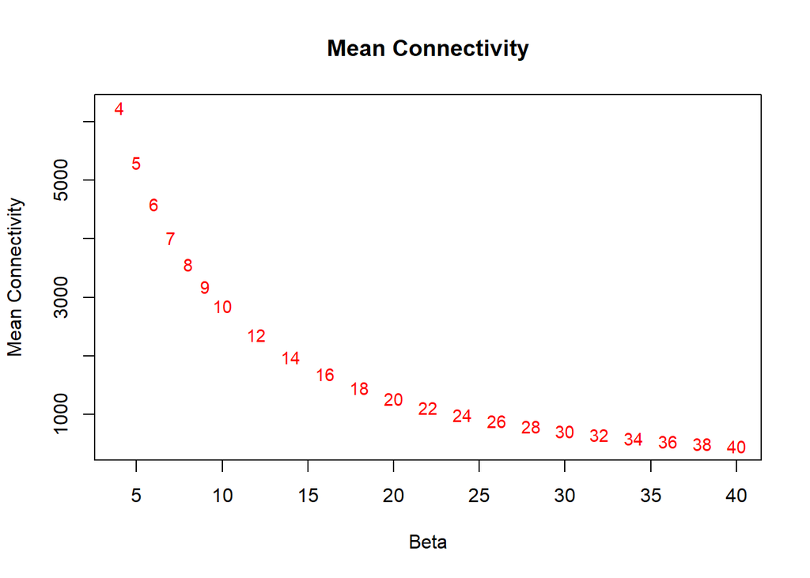

```r
plot(
  sft$fitIndices[,1],
  sft$fitIndices[,5],
  xlab="Beta", ylab="Mean Connectivity",
  type="n",
  main=paste("Mean Connectivity"))
text(
  sft$fitIndices[,1],
  sft$fitIndices[,5],
  labels=powers,
  cex=cex1,
  col="red")
```

# Adjacency Matrix and Topoological Overlap Matrix (TOM)

## Adjacency Matrix

Now we have selected the value for $\beta$, we can proceed in the calculation of the adjacency matrix. As mentioned above, this is a weighted measure of the correlation between a pair of nodes. We calculate for a signed correlation so we know the directionality of association.

```r
soft_power <- 18

adj_mat <- adjacency(
  t(varfilt_counts_matr),
  power=soft_power,
  type="signed"
)
```

## Topological Overlap Matrix (TOM)

The topological overlap matrix (TOM) is a way to measure how closely related two nodes are within a network, considering not just their direct connection (correlation) but also their shared connections (overlaps) with other genes. TOM helps make the network more robust by emphasizing groups of genes that are co-expressed in similar patterns, which is useful for identifying gene modules.

Below, we calculate the TOM from the adjacency matrix.

```r
TOM <- TOMsimilarity(adj_mat, TOMType="signed")
```

```
## ..connectivity..
## ..matrix multiplication (system BLAS)..
## ..normalization..
## ..done.
```

Afterwards, we convert TOM to a dissimilarity measure.

```r
dissTom = 1 - TOM
```

# Generate Modules

## Identify Clusters

### Create Tree

To cluster the features into modules, we have to create a dendrogram from the TOM first.

```r
gene_tree <- hclust(as.dist(dissTom), method="average")
```

### Cut Dendrogram

From the generated tree, we use the `cutreeDynamic()` function to dynamically select the heights where the tree should be cut to produce clusters. The `deepSplit` argument sets the sensitivity of the cutting. This could range from 0 to 4 where higher values produce more yet smaller clusters.

```r
dynamic_mods_ds0_pamstageF = cutreeDynamic(
  dendro=gene_tree,
  distM=dissTom,
  deepSplit=0,
  pamRespectsDendro=FALSE,
  pamStage=FALSE
)
```

```
##  ..cutHeight not given, setting it to 0.983  ===>  99% of the (truncated) height range in dendro.
##  ..done.
```

## Visualize Modules

### Modules to Colors

To make visuals more appealing, we convert the module/cluster labels to colors.

```r
dynamic_colors_ds0_pamstageF <- labels2colors(dynamic_mods_ds0_pamstageF)
```

The module sizes are summarized below. By default, the `grey` module contains the transcripts that could not be clustered into the other modules.

```r
table(dynamic_colors_ds0_pamstageF)
```

```
## dynamic_colors_ds0_pamstageF
##         black          blue         brown          cyan     darkgreen
##           405          2420          1328           215           128
##      darkgrey    darkorange       darkred darkturquoise         green
##           106            91           132           111           651
##   greenyellow          grey        grey60     lightcyan    lightgreen
##           282          3518           162           171           144
##   lightyellow       magenta  midnightblue        orange paleturquoise
##           143           357           198            98            39
##          pink        purple           red     royalblue   saddlebrown
##           371           334           415           140            69
##        salmon       skyblue     steelblue           tan     turquoise
##           270            76            42           278          3165
##         white        yellow
##            76           799
```

### Modules in Dendrogram

The plot below shows a dendrogram with module color annotations.

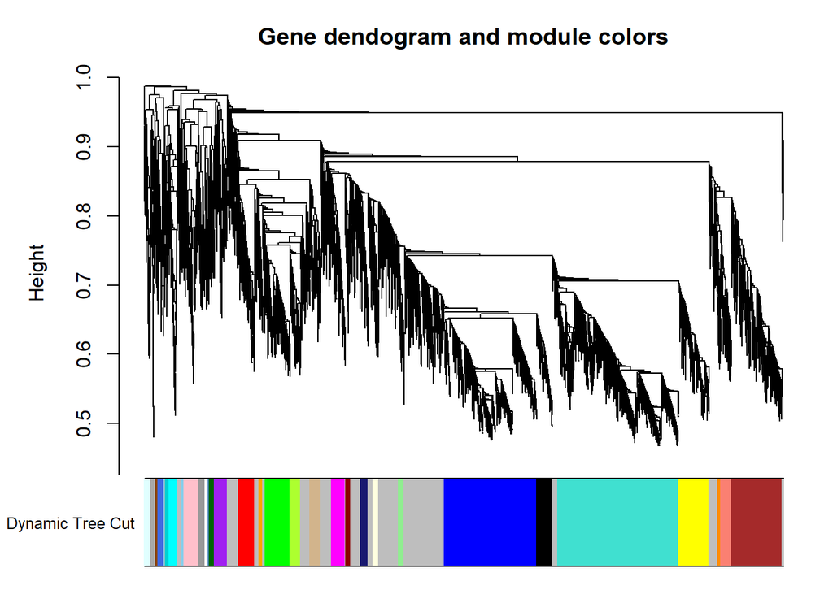

```r
plotDendroAndColors(
  gene_tree,
  dynamic_colors_ds0_pamstageF,
  "Dynamic Tree Cut",
  dendroLabels=FALSE,
  hang=0,
  addGuide=FALSE,
  guideHang=0.05,
  main="Gene dendogram and module colors"
)
```

After this step, you can refer to `WGCNA Downstream.Rmd` for subsequent steps you can do to explore your data (e.g. module-trait correlation, module membership, and gene significance).